© Bản quyền thuộc về Quantopian Inc.  
© Bản quyền sửa đổi thuộc về AI Cafe¹  
Giấy phép [Creative Commons Attribution 4.0](https://creativecommons.org/licenses/by/4.0/legalcode).  
[Khuyến cáo](https://aicafe.one/khuyen-cao/)

# Thư viện pandas

by Maxwell Margenot

Edited by AI Cafe¹

Pandas là một thư viện Python cung cấp một tập hợp các cấu trúc dữ liệu mạnh mẽ để giúp bạn quản lý dữ liệu tốt hơn. Trong bài giảng này, chúng ta sẽ đề cập đến cách sử dụng các đối tượng `Series` và `DataFrame` để xử lý dữ liệu. Những đối tượng này có sự tích hợp mạnh mẽ với NumPy, cho phép chúng ta dễ dàng thực hiện các phép tính thống kê và toán học cần thiết cho lĩnh vực tài chính.

```python
import numpy as np
import pandas as pd
import matplotlib.pyplot as plt
```

Với pandas, việc lưu trữ, trực quan hóa và thực hiện các phép tính trên dữ liệu của bạn trở nên dễ dàng. Chỉ với vài dòng mã, chúng ta có thể chỉnh sửa dữ liệu và trình bày nó theo cách dễ hiểu. Ở đây, chúng ta mô phỏng một số tỷ suất sinh lợi trong NumPy, đưa chúng vào một `DataFrame` của pandas và thực hiện các phép tính để chuyển chúng thành giá cả và vẽ đồ thị, tất cả chỉ với vài dòng mã.

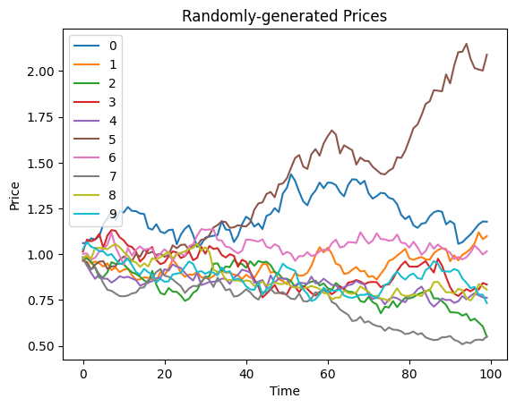

```python
returns = pd.DataFrame(np.random.normal(1.0, 0.03, (100, 10)))
prices = returns.cumprod()
prices.plot()
plt.title('Randomly-generated Prices')
plt.xlabel('Time')
plt.ylabel('Price')
plt.legend(loc=0);
```

Vậy hãy cùng xem xét cách chúng ta đi từng bước đến điểm này nhé!

## Cấu trúc dữ liệu trong pandas

### `Series`

Một `Series` trong pandas là một mảng 1 chiều với các nhãn có thể chứa bất kỳ loại dữ liệu nào. Chúng được sử dụng chủ yếu để xử lý dữ liệu chuỗi thời gian. Việc tạo một `Series` rất đơn giản, chỉ cần gọi `pandas.Series()` trên một danh sách Python hoặc mảng NumPy.

```python
s = pd.Series([1, 2, np.nan, 4, 5])
print(s)
```

```
0    1.0
1    2.0
2    NaN
3    4.0
4    5.0
dtype: float64
```

Mỗi `Series` đều có một tên. Chúng ta có thể đặt tên cho chuỗi dữ liệu này qua tham số hoặc có thể định nghĩa sau đó bằng cách truy cập trực tiếp vào thuộc tính tên. Trong trường hợp này, chúng ta đã không đặt tên cho chuỗi thời gian của mình, vì vậy thuộc tính này sẽ trống.

```python
print(s.name)
```

```
None
```

Tên này có thể được sửa đổi trực tiếp mà không gây hậu quả gì.

```python
s.name = "Toy Series"
print(s.name)
```

```
Toy Series
```

Chúng ta gọi các nhãn trục được thu thập của một `Series` là chỉ mục của nó. Một chỉ mục có thể được truyền vào một `Series` như một tham số hoặc được thêm vào sau, tương tự như tên của nó. Trong trường hợp không có chỉ mục, một `Series` sẽ đơn giản chứa một chỉ mục được tạo thành từ các số nguyên, bắt đầu từ $0$, như trong trường hợp của "Toy Series" của chúng ta.

```python
print(s.index)
```

```
RangeIndex(start=0, stop=5, step=1)
```

Pandas có một hàm tích hợp sẵn đặc biệt để tạo chỉ số ngày, đó là `date_range()`. Chúng ta sử dụng hàm này để tạo một chỉ số mới cho `s`.

```python
new_index = pd.date_range("2025-01-01", periods=len(s), freq="D")
print(new_index)
```

```
DatetimeIndex(['2025-01-01', '2025-01-02', '2025-01-03', '2025-01-04',
               '2025-01-05'],
              dtype='datetime64[ns]', freq='D')
```

Chỉ mục phải có độ dài chính xác bằng với `Series` đó. Mỗi chỉ mục phải khớp một-một với từng phần tử của `Series`. Khi điều này được thỏa mãn, chúng ta có thể trực tiếp sửa đổi chỉ mục của `Series`, giống như với tên, để sử dụng chỉ mục mới mang nhiều thông tin hơn (một cách tương đối).

```python
s.index = new_index
print(s.index)
```

```
DatetimeIndex(['2025-01-01', '2025-01-02', '2025-01-03', '2025-01-04',
               '2025-01-05'],
              dtype='datetime64[ns]', freq='D')
```

Chỉ số của `Series` rất quan trọng trong việc xử lý chuỗi thời gian, điều này chúng ta sẽ tìm hiểu kỹ hơn ở phần sau.

#### Truy cập các phần tử của `Series`

`Series` thường được truy cập bằng cách sử dụng các phương thức `iloc[]` và `loc[]`. Chúng ta sử dụng `iloc[]` để truy cập các phần tử theo chỉ số nguyên và sử dụng `loc[]` để truy cập theo chỉ số của `Series`.

```python
print("First element of the series:", s.iloc[0])
print("Last element of the series:", s.iloc[len(s)-1])
```

```
First element of the series: 1.0
Last element of the series: 5.0
```

Chúng ta có thể cắt (slice) một `Series` tương tự như collections, Python lists và NumPy arrays. Chúng ta sử dụng toán tử hai chấm để chỉ định phần cắt.

```python
s.iloc[:2]
```

|  | Toy Series |
| --- | --- |
| 2025-01-01 | 1.0 |
| 2025-01-02 | 2.0 |

**dtype:** float64

Khi tạo một đoạn cắt, chúng ta có các tùy chọn để chỉ định một điểm bắt đầu, một điểm kết thúc và một bước nhảy. Đoạn cắt sẽ bắt đầu từ chỉ số bắt đầu và lấy các bước có kích thước step cho đến khi vượt qua chỉ số kết thúc, không bao gồm chỉ số kết thúc.

```python
start = 0
end = len(s) - 1
step = 1

s.iloc[start:end:step]
```

|  | Toy Series |
| --- | --- |
| 2025-01-01 | 1.0 |
| 2025-01-02 | 2.0 |
| 2025-01-03 | NaN |
| 2025-01-04 | 4.0 |

**dtype:** float64

Chúng ta thậm chí có thể đảo ngược một Series bằng cách chỉ định kích thước bước âm.

```python
s.iloc[::-1]
```

|  | Toy Series |
| --- | --- |
| 2025-01-05 | 5.0 |
| 2025-01-04 | 4.0 |
| 2025-01-03 | NaN |
| 2025-01-02 | 2.0 |
| 2025-01-01 | 1.0 |

**dtype:** float64

Tương tự, chúng ta có thể chỉ mục cho điểm bắt đầu và kết thúc bằng một giá trị nguyên âm.

```python
s.iloc[-2:-4:-1]
```

|  | Toy Series |
| --- | --- |
| 2025-01-04 | 4.0 |
| 2025-01-03 | NaN |

**dtype:** float64

Chúng ta cũng có thể truy cập một chuỗi bằng cách sử dụng các giá trị của chỉ số của nó. Vì chúng ta đã lập chỉ mục cho `s` bằng một tập hợp các ngày tháng (các đối tượng `Timestamp`), nên chúng ta có thể xem giá trị chứa trong `s` cho một ngày cụ thể.

```python
s.loc['2025-01-01']
```

```
np.float64(1.0)
```

Hoặc thậm chí cho một khoảng thời gian cụ thể!

```python
s.loc['2025-01-02':'2025-01-04']
```

|  | Toy Series |
| --- | --- |
| 2025-01-02 | 2.0 |
| 2025-01-03 | NaN |
| 2025-01-04 | 4.0 |

**dtype:** float64

Với `Series`, chúng ta *có thể* chỉ sử dụng dấu ngoặc vuông (`[]`) để truy cập các phần tử, nhưng đây không phải là cách viết tốt nhất. Dấu ngoặc vuông có thể gây nhầm lẫn vì chúng có thể được sử dụng để truy cập `Series` (và `DataFrames`) bằng cả giá trị chỉ số và giá trị số nguyên, và kết quả sẽ thay đổi dựa trên ngữ cảnh (đặc biệt là với `DataFrames`).

#### Lập chỉ mục Boolean

Ngoài các phương pháp truy cập đã đề cập ở trên, bạn có thể lọc `Series` bằng cách sử dụng các mảng boolean. `Series` tương thích với các toán tử so sánh tiêu chuẩn của bạn. Khi được so sánh với bất kỳ điều kiện nào mà bạn thích, bạn sẽ nhận được một `Series` khác, lần này được lấp đầy bằng các giá trị boolean.

```python
print(s < 3)
```

```
2025-01-01     True
2025-01-02     True
2025-01-03    False
2025-01-04    False
2025-01-05    False
Freq: D, Name: Toy Series, dtype: bool
```

Chúng ta có thể đưa lại *chuỗi* `Series` này vào chuỗi `Series` gốc để lọc ra chỉ những phần tử mà điều kiện của chúng là `True`.

```python
print(s.loc[s < 3])
```

```
2025-01-01    1.0
2025-01-02    2.0
Freq: D, Name: Toy Series, dtype: float64
```

Nếu muốn, chúng ta có thể nhóm nhiều điều kiện lại với nhau bằng cách sử dụng các toán tử logic `&`, `|`, và `~` (và, hoặc, và không, tương ứng).

```python
print(s.loc[(s < 3) & (s > 1)])
```

```
2025-01-02    2.0
Freq: D, Name: Toy Series, dtype: float64
```

Điều này rất tiện lợi để lấy chỉ những phần tử của một `Series` đáp ứng các tiêu chí cụ thể mà chúng ta cần. Nó trở nên thuận tiện hơn khi chúng ta làm việc với `DataFrames`.

#### Lập chỉ mục và Dữ liệu chuỗi thời gian (Time Series)

Vì chúng ta sử dụng `Series` để xử lý dữ liệu chuỗi thời gian, nên việc tìm hiểu một chút về cách chúng ta xử lý thành phần thời gian là điều đáng lưu tâm. Đối với mục đích của chúng ta, chúng ta sử dụng các đối tượng `Timestamp` của pandas. Hãy lấy một chuỗi thời gian đầy đủ, hoàn chỉnh với tất cả các nhãn phù hợp, bằng cách sử dụng hàm `get_prices()`. Tất cả dữ liệu được lấy với `get_prices()` sẽ ở định dạng `DataFrame`. Chúng ta có thể sửa đổi chỉ mục này theo cách mà chúng ta muốn.

```python
# Cài thư viện lấy dữ liệu miễn phí
!curl -fsSLO https://raw.githubusercontent.com/algo-stocks/data/master/data.py
```

```python
from data import get_prices
start = "2021-01-01"
end = "2025-01-01"
prices = get_prices("VNINDEX", start_date=start, end_date=end)
prices = prices['VNINDEX']
```

Chúng ta có thể hiển thị một vài phần tử đầu tiên của chuỗi bằng cách sử dụng phương thức `head()` và chỉ định số lượng phần tử mà chúng ta muốn. Phương thức tương tự cho vài phần tử cuối cùng là `tail()`.

```python
print(type(prices))
prices.head(5)
```

```
<class 'pandas.core.series.Series'>
```

| date | VNINDEX |
| --- | --- |
| 2021-01-04 | 1120.47 |
| 2021-01-05 | 1132.55 |
| 2021-01-06 | 1143.21 |
| 2021-01-07 | 1156.49 |
| 2021-01-08 | 1167.69 |

**dtype:** float64

Hãy cùng xem xét kỹ hơn về `DatetimeIndex` của chuỗi thời gian `prices` của chúng ta.

```python
print(prices.index)
print("tz:", prices.index.tz)
```

```
DatetimeIndex(['2021-01-04', '2021-01-05', '2021-01-06', '2021-01-07',
               '2021-01-08', '2021-01-11', '2021-01-12', '2021-01-13',
               '2021-01-14', '2021-01-15',
               ...
               '2024-12-18', '2024-12-19', '2024-12-20', '2024-12-23',
               '2024-12-24', '2024-12-25', '2024-12-26', '2024-12-27',
               '2024-12-30', '2024-12-31'],
              dtype='datetime64[ns]', name='date', length=997, freq=None)
tz: None
```

Lưu ý rằng `DatetimeIndex` này có một tập hợp thông tin liên quan. Cụ thể, nó có một tần suất liên quan (`freq`) và một múi giờ liên quan (`tz`). Tần suất cho biết dữ liệu là hàng ngày, hàng tháng hay một khoảng thời gian khác, trong khi múi giờ cho biết chỉ số này tương đối với địa phương nào. Chúng ta có thể điều chỉnh tất cả thông tin bổ sung này!

Nếu chúng ta lấy mẫu lại `Series`, chúng ta có thể điều chỉnh tần suất của dữ liệu. Hiện tại, chúng ta có dữ liệu hàng ngày (không bao gồm cuối tuần). Hãy giảm xuống từ dữ liệu hàng ngày này xuống dữ liệu hàng tháng bằng cách sử dụng phương thức `resample()`.

```python
monthly_prices = prices.resample('ME').last()
monthly_prices.head(10)
```

| date | VNINDEX |
| --- | --- |
| 2021-01-31 | 1056.61 |
| 2021-02-28 | 1168.47 |
| 2021-03-31 | 1191.44 |
| 2021-04-30 | 1239.39 |
| 2021-05-31 | 1328.05 |
| 2021-06-30 | 1408.55 |
| 2021-07-31 | 1310.05 |
| 2021-08-31 | 1331.47 |
| 2021-09-30 | 1342.06 |
| 2021-10-31 | 1444.27 |

**dtype:** float64

Trong ví dụ trên, chúng ta sử dụng giá trị cuối cùng của dữ liệu cấp thấp để tạo ra dữ liệu cấp cao hơn. Chúng ta có thể chỉ định những cách khác mà chúng ta muốn tính toán việc giảm mẫu, chẳng hạn như sử dụng giá trị trung vị.

```python
monthly_prices_med = prices.resample('ME').median()
monthly_prices_med.head(10)
```

| date | VNINDEX |
| --- | --- |
| 2021-01-31 | 1160.350 |
| 2021-02-28 | 1155.780 |
| 2021-03-31 | 1181.730 |
| 2021-04-30 | 1239.050 |
| 2021-05-31 | 1264.425 |
| 2021-06-30 | 1365.820 |
| 2021-07-31 | 1295.110 |
| 2021-08-31 | 1338.095 |
| 2021-09-30 | 1343.020 |
| 2021-10-31 | 1391.850 |

**dtype:** float64

Chúng ta thậm chí có thể chỉ định cách chúng ta muốn thực hiện tính toán cho khoảng thời gian mới. Ở đây, chúng ta tạo một hàm `custom_resampler()` sẽ trả về giá trị đầu tiên của khoảng thời gian. Trong trường hợp cụ thể của chúng ta, điều này sẽ trả về một `Series` trong đó giá trị hàng tháng là giá trị đầu tiên của tháng đó.

```python
def custom_resampler(array_like):
    """ Returns the first value of the period """
    return array_like.iloc[0]

first_of_month_prices = prices.resample('ME').apply(custom_resampler)
first_of_month_prices.head(10)
```

| date | VNINDEX |
| --- | --- |
| 2021-01-31 | 1120.47 |
| 2021-02-28 | 1035.51 |
| 2021-03-31 | 1186.17 |
| 2021-04-30 | 1216.10 |
| 2021-05-31 | 1242.20 |
| 2021-06-30 | 1337.78 |
| 2021-07-31 | 1417.08 |
| 2021-08-31 | 1314.22 |
| 2021-09-30 | 1334.65 |
| 2021-10-31 | 1334.89 |

**dtype:** float64

Chúng ta cũng có thể điều chỉnh múi giờ của một `Series` để phù hợp với thời gian của dữ liệu thực tế. Trong trường hợp của chúng ta, chuỗi thời gian của chúng ta không được định vị theo một múi giờ nào, nhưng giả sử rằng chúng ta muốn định vị thời gian thành 'Asia/Ho_Chi_Minh'. Trong trường hợp này, chúng ta sử dụng phương thức `tz_localize()`, vì thời gian chưa được định vị trước đó.

```python
eastern_prices = prices.tz_localize('Asia/Ho_Chi_Minh')
eastern_prices.head(10)
```

| date | VNINDEX |
| --- | --- |
| 2021-01-04 00:00:00+07:00 | 1120.47 |
| 2021-01-05 00:00:00+07:00 | 1132.55 |
| 2021-01-06 00:00:00+07:00 | 1143.21 |
| 2021-01-07 00:00:00+07:00 | 1156.49 |
| 2021-01-08 00:00:00+07:00 | 1167.69 |
| 2021-01-11 00:00:00+07:00 | 1184.89 |
| 2021-01-12 00:00:00+07:00 | 1192.28 |
| 2021-01-13 00:00:00+07:00 | 1186.05 |
| 2021-01-14 00:00:00+07:00 | 1187.40 |
| 2021-01-15 00:00:00+07:00 | 1194.20 |

**dtype:** float64

Ngoài khả năng quản lý múi giờ và tần suất, mỗi chuỗi thời gian đều có phương thức `reindex()` được tích hợp sẵn mà chúng ta có thể sử dụng để điều chỉnh lại dữ liệu hiện có theo một tập hợp nhãn chỉ mục mới. Nếu dữ liệu không tồn tại cho một nhãn cụ thể, dữ liệu sẽ được điền bằng một giá trị giữ chỗ. Thông thường đó là `np.nan`, mặc dù chúng ta có thể cung cấp một phương thức điền giá trị này.

Dữ liệu mà chúng ta nhận được từ `get_prices()` chỉ bao gồm các ngày giao dịch trên thị trường. Nhưng nếu chúng ta muốn có giá cho từng ngày trong lịch, bao gồm cả ngày lễ và cuối tuần, những thời điểm mà bạn thường không thể giao dịch cổ phiếu. Đầu tiên, hãy tạo một `DatetimeIndex` mới chứa tất cả những gì chúng ta muốn.

```python
calendar_dates = pd.date_range(start=start, end=end, freq='D')
print(calendar_dates)
```

```
DatetimeIndex(['2021-01-01', '2021-01-02', '2021-01-03', '2021-01-04',
               '2021-01-05', '2021-01-06', '2021-01-07', '2021-01-08',
               '2021-01-09', '2021-01-10',
               ...
               '2024-12-23', '2024-12-24', '2024-12-25', '2024-12-26',
               '2024-12-27', '2024-12-28', '2024-12-29', '2024-12-30',
               '2024-12-31', '2025-01-01'],
              dtype='datetime64[ns]', length=1462, freq='D')
```

Bây giờ hãy sử dụng bộ ngày mới này để tái chỉ mục chuỗi thời gian của chúng ta. Chúng ta thông báo cho hàm rằng phương pháp điền mà chúng ta muốn là `ffill`. Điều này có nghĩa là "điền tiến". Bất kỳ giá trị `NaN` nào sẽ được điền bằng *giá trị cuối cùng* được liệt kê. Vì vậy, giá vào cuối tuần hoặc vào ngày lễ sẽ được liệt kê là giá vào ngày giao dịch cuối cùng mà chúng ta biết.

```python
calendar_prices = prices.reindex(calendar_dates, method='ffill')
calendar_prices.head(15)
```

|  | VNINDEX |
| --- | --- |
| 2021-01-01 | NaN |
| 2021-01-02 | NaN |
| 2021-01-03 | NaN |
| 2021-01-04 | 1120.47 |
| 2021-01-05 | 1132.55 |
| 2021-01-06 | 1143.21 |
| 2021-01-07 | 1156.49 |
| 2021-01-08 | 1167.69 |
| 2021-01-09 | 1167.69 |
| 2021-01-10 | 1167.69 |
| 2021-01-11 | 1184.89 |
| 2021-01-12 | 1192.28 |
| 2021-01-13 | 1186.05 |
| 2021-01-14 | 1187.40 |
| 2021-01-15 | 1194.20 |

**dtype:** float64

Bạn sẽ nhận thấy rằng chúng ta vẫn có một vài giá trị `NaN` ngay ở đầu chuỗi thời gian của chúng ta. Điều này là do ngày 1 tháng 1 năm 2021 là một ngày lễ, theo sau là những ngày nghỉ cuối tuần! Bởi vì đây là những điểm dữ liệu sớm nhất và chúng ta không có thông tin nào từ trước đó, nên chúng không thể được điền giá trị phía trước. Chúng ta sẽ xử lý những giá trị `NaN` này trong phần tiếp theo, khi chúng ta giải quyết vấn đề dữ liệu bị thiếu.

#### Dữ liệu bị thiếu

Khi chúng ta xử lý dữ liệu thực, có khả năng rất thực tế là gặp phải các giá trị bị thiếu. Dữ liệu thực thường có nhiều lỗ hổng và pandas cung cấp cho chúng ta những cách để xử lý chúng. Đôi khi, việc lấy mẫu lại hoặc thay đổi chỉ mục có thể tạo ra các giá trị `NaN`. May mắn thay, pandas cung cấp cho chúng ta các phương pháp để xử lý chúng. Chúng ta có hai phương pháp chính để đối phó với dữ liệu bị thiếu. Phương pháp đầu tiên là điền vào dữ liệu bị thiếu bằng hàm `fillna()`. Ví dụ, giả sử rằng chúng ta muốn điền vào các ngày bị thiếu với giá trung bình của tất cả các ngày.

```python
meanfilled_prices = calendar_prices.fillna(calendar_prices.mean())
meanfilled_prices.head(10)
```

|  | VNINDEX |
| --- | --- |
| 2021-01-01 | 1231.596628 |
| 2021-01-02 | 1231.596628 |
| 2021-01-03 | 1231.596628 |
| 2021-01-04 | 1120.470000 |
| 2021-01-05 | 1132.550000 |
| 2021-01-06 | 1143.210000 |
| 2021-01-07 | 1156.490000 |
| 2021-01-08 | 1167.690000 |
| 2021-01-09 | 1167.690000 |
| 2021-01-10 | 1167.690000 |

**dtype:** float64

Sử dụng `fillna()` thì khá dễ dàng. Chỉ cần chỉ định giá trị mà bạn muốn điền vào các khoảng trống. Tuy nhiên, trường hợp này không thực sự hợp lý, vì những lý do đã được thảo luận trong bài giảng về tính dừng trong chuỗi bài giảng. Chúng ta có thể điền chúng bằng $0$, nhưng điều đó cũng không cung cấp thông tin hữu ích.

Thay vì điền các giá trị cụ thể bằng `fillna()`, chúng ta có thể sử dụng phương thức `bfill()` để "điền lùi", nơi mà các giá trị `NaN` sẽ được điền bằng giá trị đã được điền *tiếp theo* (thay vì giá trị đã được điền *cuối cùng* trong phương pháp điền tiến).

```python
bfilled_prices = calendar_prices.bfill()
bfilled_prices.head(10)
```

|  | VNINDEX |
| --- | --- |
| 2021-01-01 | 1120.47 |
| 2021-01-02 | 1120.47 |
| 2021-01-03 | 1120.47 |
| 2021-01-04 | 1120.47 |
| 2021-01-05 | 1132.55 |
| 2021-01-06 | 1143.21 |
| 2021-01-07 | 1156.49 |
| 2021-01-08 | 1167.69 |
| 2021-01-09 | 1167.69 |
| 2021-01-10 | 1167.69 |

**dtype:** float64

Nhưng một lần nữa, đây là một ý tưởng tồi vì những lý do giống như tùy chọn trước. Cả hai giải pháp được gọi là này đều tính đến *dữ liệu tương lai* mà không có sẵn tại thời điểm các điểm dữ liệu mà chúng ta đang cố gắng lấp đầy. Trong trường hợp sử dụng trung bình hoặc trung vị, các thống kê tóm tắt này được tính toán bằng cách xem xét toàn bộ chuỗi thời gian. Việc điền lùi giống như nói rằng giá của một chứng khoán cụ thể hôm nay, ngay bây giờ, là giá của ngày mai. Điều này cũng không hợp lý. Cả hai tùy chọn này đều là ví dụ về thiên lệch nhìn trước (look-ahead bias), sử dụng dữ liệu sẽ không được biết hoặc không có sẵn vào thời điểm mong muốn, chúng ta nên tránh sử dụng như vậy.

Tùy chọn tiếp theo của chúng ta hấp dẫn hơn nhiều. Chúng ta có thể đơn giản loại bỏ dữ liệu bị thiếu bằng phương pháp `dropna()`. Đây là một lựa chọn tốt hơn nhiều so với việc điền các giá trị `NaN` bằng các số tùy ý.

```python
dropped_prices = calendar_prices.dropna()
dropped_prices.head(10)
```

|  | VNINDEX |
| --- | --- |
| 2021-01-04 | 1120.47 |
| 2021-01-05 | 1132.55 |
| 2021-01-06 | 1143.21 |
| 2021-01-07 | 1156.49 |
| 2021-01-08 | 1167.69 |
| 2021-01-09 | 1167.69 |
| 2021-01-10 | 1167.69 |
| 2021-01-11 | 1184.89 |
| 2021-01-12 | 1192.28 |
| 2021-01-13 | 1186.05 |

**dtype:** float64

Bây giờ chuỗi thời gian của chúng ta đã được làm sạch cho năm dương lịch, với tất cả các giá trị `NaN` được xử lý đúng cách. Đã đến lúc nói về cách thực hiện phân tích chuỗi thời gian thực sự với các cấu trúc dữ liệu pandas.

#### Phân tích chuỗi thời gian với pandas

Hãy thực hiện một số phân tích chuỗi thời gian cơ bản trên các giá gốc của chúng ta. Mỗi `Series` trong pandas có một phương thức vẽ đồ thị tích hợp sẵn.

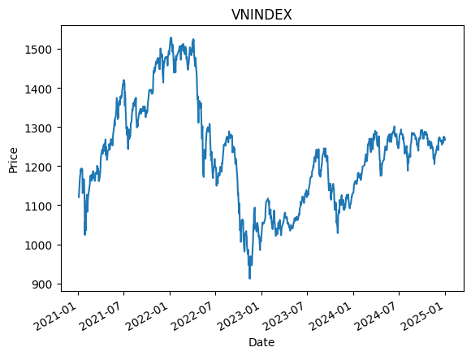

```python
prices.plot();
# We still need to add the axis labels and title ourselves
plt.title("VNINDEX")
plt.ylabel("Price")
plt.xlabel("Date");
```

Cũng như một số thống kê mô tả tích hợp sẵn. Chúng ta có thể tính toán chúng một cách riêng lẻ hoặc sử dụng phương thức `describe()`.

```python
print("Mean:", prices.mean())
print("Standard deviation:", prices.std())
```

```
Mean: 1231.0853660982948
Standard deviation: 133.3070761859112
```

```python
print("Summary Statistics")
print(prices.describe())
```

```
Summary Statistics
count     997.000000
mean     1231.085366
std       133.307076
min       911.900000
25%      1127.630000
50%      1238.840000
75%      1288.620000
max      1528.570000
Name: VNINDEX, dtype: float64
```

Chúng ta có thể dễ dàng sửa đổi `Series` với các số vô hướng bằng cách sử dụng các toán tử toán học cơ bản của chúng ta.

```python
modified_prices = prices * 2 - 10
modified_prices.head(5)
```

| date | VNINDEX |
| --- | --- |
| 2021-01-04 | 2230.94 |
| 2021-01-05 | 2255.10 |
| 2021-01-06 | 2276.42 |
| 2021-01-07 | 2302.98 |
| 2021-01-08 | 2325.38 |

**dtype:** float64

Và chúng ta có thể tạo ra các tổ hợp tuyến tính của chính các `Series` bằng cách sử dụng các toán tử toán học cơ bản. pandas sẽ nhóm các chỉ số khớp lại với nhau và thực hiện các phép toán theo từng phần tử để tạo ra một `Series` mới.

```python
noisy_prices = prices + 5 * pd.Series(np.random.normal(0, 5, len(prices)), index=prices.index) + 20
noisy_prices.head(5)
```

| date | 0 |
| --- | --- |
| 2021-01-04 | 1121.644606 |
| 2021-01-05 | 1174.732751 |
| 2021-01-06 | 1175.317657 |
| 2021-01-07 | 1164.612432 |
| 2021-01-08 | 1194.585192 |

**dtype:** float64

Nếu không có chỉ số nào phù hợp, chúng ta có thể nhận được một `Series` rỗng.

```python
empty_series = prices + pd.Series(np.random.normal(0, 1, len(prices)))
empty_series.head(5)
```

|  | 0 |
| --- | --- |
| 2021-01-04 00:00:00 | NaN |
| 2021-01-05 00:00:00 | NaN |
| 2021-01-06 00:00:00 | NaN |
| 2021-01-07 00:00:00 | NaN |
| 2021-01-08 00:00:00 | NaN |

**dtype:** float64

Thay vì nhìn vào chuỗi thời gian tự nó, chúng ta có thể muốn xem xét sự khác biệt bậc nhất của nó hoặc thay đổi phần trăm (để có được lợi nhuận cộng hoặc nhân, trong trường hợp cụ thể của chúng ta). Cả hai đều là những phương pháp có sẵn.

```python
add_returns = prices.diff()[1:]
mult_returns = prices.pct_change()[1:]
```

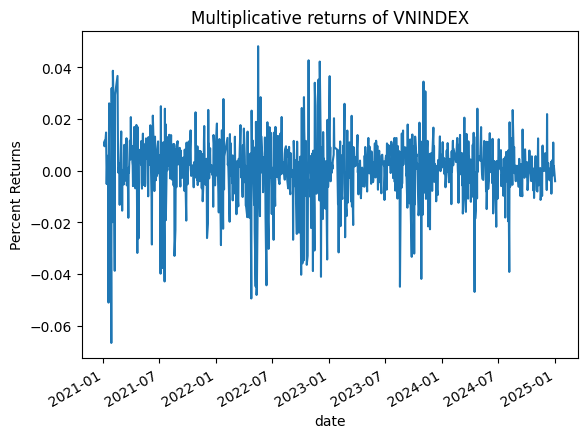

```python
plt.title("Multiplicative returns of VNINDEX")
plt.xlabel("Date")
plt.ylabel("Percent Returns")
mult_returns.plot();
```

Pandas có các hàm tiện lợi để tính toán trung bình động và độ lệch chuẩn, cũng như vậy!

```python
rolling_mean = prices.rolling(30).mean()
rolling_mean.name = "30-day rolling mean"
```

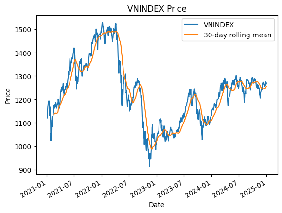

```python
prices.plot()
rolling_mean.plot()
plt.title("VNINDEX Price")
plt.xlabel("Date")
plt.ylabel("Price")
plt.legend();
```

```python
rolling_std = prices.rolling(30).std()
rolling_std.name = "30-day rolling volatility"
```

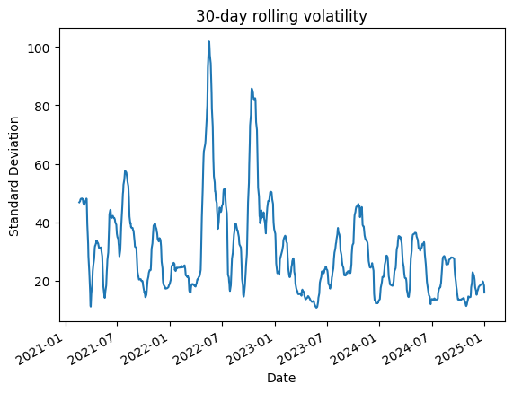

```python
rolling_std.plot()
plt.title(rolling_std.name);
plt.xlabel("Date")
plt.ylabel("Standard Deviation");
```

Nhiều hàm NumPy sẽ hoạt động trên `Series` tương tự như cách chúng hoạt động trên các mảng NumPy 1 chiều.

```python
print(np.median(mult_returns))
```

```
0.0009848297169151587
```

Hầu hết các chức năng này, tuy nhiên, đã được triển khai trực tiếp dưới dạng các phương thức của `Series` và `DataFrame`.

```python
print(mult_returns.median())
```

```
0.0009848297169151587
```

Trong mọi trường hợp, việc sử dụng phương thức tích hợp sẵn của pandas sẽ tốt hơn so với việc sử dụng hàm NumPy trên một cấu trúc dữ liệu pandas do những cải tiến về hiệu suất. Hãy chắc chắn kiểm tra [tài liệu](http://pandas.pydata.org/pandas-docs/stable/generated/pandas.Series.html) về `Series` trước khi tìm đến các phép tính khác cho các hàm thông thường.

### `DataFrames`

Nhiều khía cạnh trong việc làm việc với `Series` cũng áp dụng cho `DataFrames`. `DataFrames` trong pandas cho phép chúng ta dễ dàng quản lý dữ liệu của mình với cấu trúc trực quan.

Giống như `Series`, `DataFrames` có thể chứa nhiều loại dữ liệu khác nhau, nhưng `DataFrames` là đối tượng 2 chiều, không giống như `Series`. Mỗi `DataFrame` có một thuộc tính chỉ mục (index) và thuộc tính cột (columns), mà chúng ta sẽ đề cập chi tiết hơn khi bắt đầu thực sự làm việc với một đối tượng. Thuộc tính chỉ mục giống như chỉ mục của một `Series`, mặc dù chỉ mục trong pandas có một số tính năng bổ sung mà chúng tôi rất tiếc là không thể đề cập ở đây. Nếu bạn quan tâm đến điều này, hãy xem tài liệu [pandas](https://pandas.pydata.org/docs/user_guide/advanced.html) về lập chỉ mục nâng cao. Thuộc tính cột cung cấp chiều thứ hai cho các `DataFrame`, cho phép chúng ta kết hợp các cột đã đặt tên (tất cả là `Series`), thành một đối tượng đồng nhất với chỉ mục được căn chỉnh.

Chúng ta có thể tạo một `DataFrame` bằng cách gọi `pandas.DataFrame()` trên một từ điển hoặc mảng NumPy (`ndarray`). Chúng ta cũng có thể nối một nhóm các `Series` của pandas thành một `DataFrame` bằng cách sử dụng `pandas.concat()`.

```python
dict_data = {
    'a' : [1, 2, 3, 4, 5],
    'b' : ['L', 'K', 'J', 'M', 'Z'],
    'c' : np.random.normal(0, 1, 5)
}
print(dict_data)
```

```
{'a': [1, 2, 3, 4, 5], 'b': ['L', 'K', 'J', 'M', 'Z'], 'c': array([0.30945519, 0.17517803, 0.45152922, 0.42528089, 0.28562943])}
```

Mỗi `DataFrame` có một số thuộc tính quan trọng mà chúng ta cần ghi nhớ. Thuộc tính đầu tiên trong số này là thuộc tính chỉ mục. Chúng ta có thể dễ dàng bao gồm một chỉ mục của các đối tượng `Timestamp` giống như chúng ta đã làm với `Series`.

```python
frame_data = pd.DataFrame(dict_data, index=pd.date_range('2025-01-01', periods=5))
print(frame_data)
```

```
            a  b         c
2025-01-01  1  L  0.309455
2025-01-02  2  K  0.175178
2025-01-03  3  J  0.451529
2025-01-04  4  M  0.425281
2025-01-05  5  Z  0.285629
```

Như đã đề cập ở trên, chúng ta có thể kết hợp `Series` thành `DataFrames`. Việc nối `Series` như thế này sẽ ghép các phần tử dựa trên chỉ số tương ứng của chúng. Vì các `Series` dưới đây không có chỉ số được gán, nên chúng mỗi cái sẽ mặc định sử dụng chỉ số số nguyên.

```python
s_1 = pd.Series([2, 4, 6, 8, 10], name='Evens')
s_2 = pd.Series([1, 3, 5, 7, 9], name="Odds")
numbers = pd.concat([s_1, s_2], axis=1)
print(numbers)
```

```
   Evens  Odds
0      2     1
1      4     3
2      6     5
3      8     7
4     10     9
```

Mỗi `DataFrame` cũng có thuộc tính `columns`. Những thuộc tính này có thể được gán khi chúng ta gọi `pandas.DataFrame` hoặc có thể được sửa đổi trực tiếp giống như chỉ số. Lưu ý rằng khi chúng ta nối hai `Series` ở trên, tên cột là tên của những `Series` đó.

```python
print(numbers.columns)
```

```
Index(['Evens', 'Odds'], dtype='object')
```

Để sửa đổi các cột sau khi tạo đối tượng, chúng ta chỉ cần làm như sau:

```python
numbers.columns = ['Shmevens', 'Shmodds']
print(numbers)
```

```
   Shmevens  Shmodds
0         2        1
1         4        3
2         6        5
3         8        7
4        10        9
```

Trong cùng một bối cảnh, chỉ số của một `DataFrame` có thể được thay đổi sau khi đã tạo.

```python
print(numbers.index)
```

```
RangeIndex(start=0, stop=5, step=1)
```

```python
numbers.index = pd.date_range("2016-01-01", periods=len(numbers))
print(numbers)
```

```
            Shmevens  Shmodds
2016-01-01         2        1
2016-01-02         4        3
2016-01-03         6        5
2016-01-04         8        7
2016-01-05        10        9
```

Ngoài việc tách biệt các cột và chỉ mục của một `DataFrame`, chúng ta cũng có thể truy cập trực tiếp vào các giá trị mà nó chứa bằng cách xem thuộc tính values.

```python
numbers.values
```

```
array([[ 2,  1],
       [ 4,  3],
       [ 6,  5],
       [ 8,  7],
       [10,  9]])
```

Giá trị này là một mảng NumPy

```python
type(numbers.values)
```

```
numpy.ndarray
```

#### Truy cập các phần tử của `DataFrame`

Một lần nữa, chúng ta thấy nhiều điểm tương đồng từ `Series` trong cách chúng ta truy cập các phần tử của `DataFrame`. Điểm quan trọng ở đây là mọi thứ đều phải xem xét đến nhiều chiều. Cách chính mà điều này diễn ra là thông qua việc truy cập vào các cột của `DataFrame`, hoặc một cách riêng lẻ hoặc theo nhóm. Chúng ta có thể thực hiện điều này bằng cách truy cập trực tiếp vào các thuộc tính hoặc bằng cách sử dụng các phương thức mà chúng ta đã quen thuộc.

Chúng ta hãy bắt đầu bằng cách tải dữ liệu giá cho một số chứng khoán:

```python
start = "2021-01-01"
end = "2025-01-01"

prices = get_prices('FPT', 'BID', 'VCB', 'VNINDEX', start_date=start, end_date=end)
prices.head()
```

| date | FPT | BID | VCB | VNINDEX |
| --- | --- | --- | --- | --- |
| 2021-01-04 | 30.4930 | 28.0029 | 43.4089 | 1120.47 |
| 2021-01-05 | 31.7593 | 27.7998 | 43.5405 | 1132.55 |
| 2021-01-06 | 31.6073 | 28.3221 | 46.0398 | 1143.21 |
| 2021-01-07 | 31.6580 | 28.3801 | 46.9167 | 1156.49 |
| 2021-01-08 | 32.0632 | 28.1480 | 45.9521 | 1167.69 |

Tại đây, chúng ta trực tiếp truy cập vào cột `VNINDEX`. Lưu ý rằng kiểu truy cập này chỉ hoạt động nếu tên cột của bạn không có khoảng trắng hoặc các ký tự đặc biệt.

```python
prices.VNINDEX.head()
```

| date | VNINDEX |
| --- | --- |
| 2021-01-04 | 1120.47 |
| 2021-01-05 | 1132.55 |
| 2021-01-06 | 1143.21 |
| 2021-01-07 | 1156.49 |
| 2021-01-08 | 1167.69 |

**dtype:** float64

Chúng ta cũng có thể truy cập cột bằng cách sử dụng tên cột trong dấu ngoặc:

```python
prices['VNINDEX'].head()
```

| date | VNINDEX |
| --- | --- |
| 2021-01-04 | 1120.47 |
| 2021-01-05 | 1132.55 |
| 2021-01-06 | 1143.21 |
| 2021-01-07 | 1156.49 |
| 2021-01-08 | 1167.69 |

**dtype:** float64

Chúng ta cũng có thể sử dụng loc[] để truy cập vào một cột riêng lẻ như sau:

```python
prices.loc[:, 'VNINDEX'].head()
```

| date | VNINDEX |
| --- | --- |
| 2021-01-04 | 1120.47 |
| 2021-01-05 | 1132.55 |
| 2021-01-06 | 1143.21 |
| 2021-01-07 | 1156.49 |
| 2021-01-08 | 1167.69 |

**dtype:** float64

Truy cập một cột riêng lẻ sẽ trả về một Series, bất kể chúng ta lấy nó như thế nào.

```python
print(type(prices.VNINDEX))
print(type(prices.loc[:, 'VNINDEX']))
```

```
<class 'pandas.core.series.Series'>
<class 'pandas.core.series.Series'>
```

Hãy chú ý cách chúng ta truyền một tuple vào phương thức `loc[]`? Đây là một sự khác biệt chính giữa việc truy cập một `Series` và truy cập một `DataFrame`, dựa trên thực tế rằng một `DataFrame` có nhiều chiều. Khi bạn truyền một tuple hai chiều vào một `DataFrame`, phần tử đầu tiên của tuple sẽ được áp dụng cho các hàng và phần tử thứ hai sẽ được áp dụng cho các cột. Vì vậy, để phân tích, dòng mã trên yêu cầu `DataFrame` trả về tất cả các hàng của cột có nhãn `'VNINDEX'`. Các danh sách cột cũng được hỗ trợ.

```python
prices.loc[:, ['VNINDEX', 'FPT']].head()
```

| date | VNINDEX | FPT |
| --- | --- | --- |
| 2021-01-04 | 1120.47 | 30.4930 |
| 2021-01-05 | 1132.55 | 31.7593 |
| 2021-01-06 | 1143.21 | 31.6073 |
| 2021-01-07 | 1156.49 | 31.6580 |
| 2021-01-08 | 1167.69 | 32.0632 |

Chúng ta cũng có thể truy cập đơn giản vào `DataFrame` bằng giá trị chỉ mục sử dụng `loc[]`, giống như với `Series`.

```python
prices.loc['2024-12-15':'2024-12-22']
```

| date | FPT | BID | VCB | VNINDEX |
| --- | --- | --- | --- | --- |
| 2024-12-16 | 149.9 | 38.6342 | 62.2746 | 1263.79 |
| 2024-12-17 | 148.0 | 38.5102 | 62.2077 | 1261.72 |
| 2024-12-18 | 148.7 | 38.7168 | 62.2746 | 1266.00 |
| 2024-12-19 | 148.1 | 38.3863 | 61.8064 | 1254.67 |
| 2024-12-20 | 149.5 | 38.3863 | 61.8733 | 1257.50 |

Điều này cũng hoạt động tốt với danh sách các cột

```python
prices.loc['2024-12-15':'2024-12-22', ['VNINDEX', 'FPT']]
```

| date | VNINDEX | FPT |
| --- | --- | --- |
| 2024-12-16 | 1263.79 | 149.9 |
| 2024-12-17 | 1261.72 | 148.0 |
| 2024-12-18 | 1266.00 | 148.7 |
| 2024-12-19 | 1254.67 | 148.1 |
| 2024-12-20 | 1257.50 | 149.5 |

Sử dụng `iloc[]` cũng hoạt động tương tự, cho phép bạn truy cập các phần của `DataFrame` bằng chỉ số số nguyên.

```python
prices.iloc[0:2, 1]
```

| date | BID |
| --- | --- |
| 2021-01-04 | 28.0029 |
| 2021-01-05 | 27.7998 |

**dtype:** float64

```python
# Access prices with integer index in
# [1, 3, 5, 7, 9, 11, 13, ..., 99]
# and in column 0 or 2
prices.iloc[[1, 3, 5] + list(range(7, 100, 2)), [0, 2]].head(20)
```

| date | FPT | VCB |
| --- | --- | --- |
| 2021-01-05 | 31.7593 | 43.5405 |
| 2021-01-07 | 31.6580 | 46.9167 |
| 2021-01-11 | 32.7724 | 45.8205 |
| 2021-01-13 | 33.6841 | 45.9521 |
| 2021-01-15 | 33.7348 | 45.2505 |
| 2021-01-19 | 31.4047 | 43.4089 |
| 2021-01-21 | 33.2282 | 45.1628 |
| 2021-01-25 | 33.9374 | 44.9436 |
| 2021-01-27 | 31.9113 | 42.7074 |
| 2021-01-29 | 31.7593 | 40.7781 |
| 2021-02-02 | 33.4308 | 42.3127 |
| 2021-02-04 | 36.7233 | 43.3651 |
| 2021-02-08 | 36.1154 | 41.2604 |
| 2021-02-17 | 39.4585 | 43.8474 |
| 2021-02-19 | 38.8000 | 44.4174 |
| 2021-02-23 | 38.2429 | 43.8474 |
| 2021-02-25 | 38.5974 | 43.0582 |
| 2021-03-01 | 39.4585 | 43.4966 |
| 2021-03-03 | 39.3572 | 43.1458 |
| 2021-03-05 | 38.4455 | 42.2689 |

#### Lập chỉ mục Boolean

Giống như với `Series`, đôi khi chúng ta muốn lọc một `DataFrame` theo một tập hợp các tiêu chí. Chúng ta thực hiện điều này bằng cách lập chỉ mục cho `DataFrame` của mình bằng các giá trị boolean.

```python
prices.loc[prices.VCB > prices.FPT].head()
```

| date | FPT | BID | VCB | VNINDEX |
| --- | --- | --- | --- | --- |
| 2021-01-04 | 30.4930 | 28.0029 | 43.4089 | 1120.47 |
| 2021-01-05 | 31.7593 | 27.7998 | 43.5405 | 1132.55 |
| 2021-01-06 | 31.6073 | 28.3221 | 46.0398 | 1143.21 |
| 2021-01-07 | 31.6580 | 28.3801 | 46.9167 | 1156.49 |
| 2021-01-08 | 32.0632 | 28.1480 | 45.9521 | 1167.69 |

Chúng ta có thể thêm nhiều điều kiện boolean bằng cách sử dụng các toán tử logic `&`, `|`, và `~` (và, hoặc, và không, tương ứng) một lần nữa!

```python
prices.loc[(prices.VCB > prices.FPT) & ~(prices.VNINDEX > 1100)].head()
```

| date | FPT | BID | VCB | VNINDEX |
| --- | --- | --- | --- | --- |
| 2021-01-27 | 31.9113 | 23.9693 | 42.7074 | 1097.17 |
| 2021-01-28 | 29.6825 | 22.3153 | 39.7258 | 1023.94 |
| 2021-01-29 | 31.7593 | 23.1568 | 40.7781 | 1056.61 |
| 2021-02-01 | 32.1645 | 22.6925 | 39.9450 | 1035.51 |
| 2021-02-02 | 33.4308 | 22.8376 | 42.3127 | 1075.53 |

#### Thêm, Xóa Cột, Kết Hợp `DataFrames`/`Series`

Tất cả đều tốt khi bạn đã có một `DataFrame` được lấp đầy dữ liệu, nhưng cũng quan trọng không kém là có khả năng thêm vào dữ liệu mà bạn đã có.

Chúng ta thêm một cột mới chỉ đơn giản bằng cách gán dữ liệu cho một cột chưa tồn tại. Ở đây, chúng ta sử dụng ký hiệu `.loc[:, 'COL_NAME']` và lưu trữ đầu ra của `get_pricing()` (trả về một pandas `Series` nếu chúng ta chỉ truyền một chứng khoán) vào đó. Đây là phương pháp mà chúng ta sẽ sử dụng để thêm một `Series` vào một `DataFrame` hiện có.

```python
s_1 = get_prices('ACB', start_date=start, end_date=end)['ACB']
prices.loc[:, 'ACB'] = s_1
prices.head()
```

| date | FPT | BID | VCB | VNINDEX | ACB |
| --- | --- | --- | --- | --- | --- |
| 2021-01-04 | 30.4930 | 28.0029 | 43.4089 | 1120.47 | 12.8655 |
| 2021-01-05 | 31.7593 | 27.7998 | 43.5405 | 1132.55 | 13.1798 |
| 2021-01-06 | 31.6073 | 28.3221 | 46.0398 | 1143.21 | 13.4268 |
| 2021-01-07 | 31.6580 | 28.3801 | 46.9167 | 1156.49 | 13.4268 |
| 2021-01-08 | 32.0632 | 28.1480 | 45.9521 | 1167.69 | 13.5615 |

Xóa một cột cũng dễ dàng như vậy!

```python
prices = prices.drop('ACB', axis=1)
prices.head(5)
```

| date | FPT | BID | VCB | VNINDEX |
| --- | --- | --- | --- | --- |
| 2021-01-04 | 30.4930 | 28.0029 | 43.4089 | 1120.47 |
| 2021-01-05 | 31.7593 | 27.7998 | 43.5405 | 1132.55 |
| 2021-01-06 | 31.6073 | 28.3221 | 46.0398 | 1143.21 |
| 2021-01-07 | 31.6580 | 28.3801 | 46.9167 | 1156.49 |
| 2021-01-08 | 32.0632 | 28.1480 | 45.9521 | 1167.69 |

#### Phân tích chuỗi thời gian với pandas

Sử dụng các phương pháp thống kê tích hợp sẵn cho `DataFrames`, chúng ta có thể thực hiện các phép tính trên nhiều chuỗi thời gian cùng một lúc! Mã để thực hiện các phép tính trên `DataFrames` ở đây gần như hoàn toàn giống với các phương pháp được sử dụng cho `Series` ở trên, vì vậy đừng lo lắng về việc phải học lại mọi thứ.

Phương thức `plot()` lại xuất hiện ở đây, lần này với một chú thích tích hợp sẵn tương ứng với tên của các cột mà bạn đang vẽ.

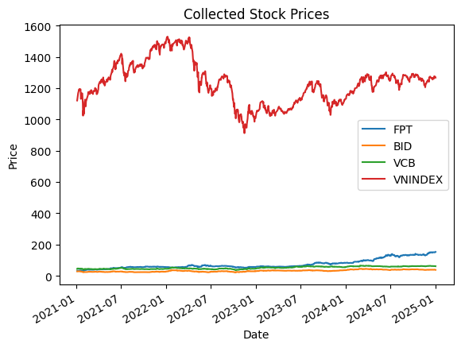

```python
prices.plot()
plt.title("Collected Stock Prices")
plt.ylabel("Price")
plt.xlabel("Date");
```

```python
prices.mean(axis=0)
```

|  | 0 |
| --- | --- |
| FPT | 73.668133 |
| BID | 31.410371 |
| VCB | 51.150068 |
| VNINDEX | 1231.085366 |

**dtype:** float64

Và độ lệch chuẩn:

```python
prices.std(axis=0)
```

|  | 0 |
| --- | --- |
| FPT | 29.725842 |
| BID | 6.110848 |
| VCB | 7.749379 |
| VNINDEX | 133.307076 |

**dtype:** float64

Một lần nữa, hàm `describe()` sẽ cung cấp cho chúng ta các thống kê tóm tắt về dữ liệu của chúng ta nếu chúng ta muốn có tất cả các số liệu thống kê thông thường của mình trong một hình thức trực quan tiện lợi thay vì tính toán chúng một cách riêng lẻ.

```python
prices.describe()
```

|  | FPT | BID | VCB | VNINDEX |
| --- | --- | --- | --- | --- |
| count | 998.000000 | 998.000000 | 998.000000 | 997.000000 |
| mean | 73.668133 | 31.410371 | 51.150068 | 1231.085366 |
| std | 29.725842 | 6.110848 | 7.749379 | 133.307076 |
| min | 29.682500 | 20.900400 | 35.114200 | 911.900000 |
| 25% | 55.609300 | 25.813800 | 43.628200 | 1127.630000 |
| 50% | 60.800950 | 31.533900 | 49.896100 | 1238.840000 |
| 75% | 82.912450 | 35.916950 | 59.069300 | 1288.620000 |
| max | 152.500000 | 44.956200 | 65.150900 | 1528.570000 |

Chúng ta có thể mở rộng và thêm các số vô hướng vào `DataFrame`, như bạn có thể đoán được sau khi làm việc với `Series`. Điều này cũng hoạt động theo từng phần tử.

```python
(2 * prices - 50).head(5)
```

| date | FPT | BID | VCB | VNINDEX |
| --- | --- | --- | --- | --- |
| 2021-01-04 | 10.9860 | 6.0058 | 36.8178 | 2190.94 |
| 2021-01-05 | 13.5186 | 5.5996 | 37.0810 | 2215.10 |
| 2021-01-06 | 13.2146 | 6.6442 | 42.0796 | 2236.42 |
| 2021-01-07 | 13.3160 | 6.7602 | 43.8334 | 2262.98 |
| 2021-01-08 | 14.1264 | 6.2960 | 41.9042 | 2285.38 |

Ở đây, chúng ta sử dụng phương pháp `pct_change()` để có được một `DataFrame` về lợi nhuận giản đơn (simple returns) của các chứng khoán mà chúng ta đang xem xét.

```python
mult_returns = prices.pct_change(fill_method=None)[1:]
mult_returns.head()
```

| date | FPT | BID | VCB | VNINDEX |
| --- | --- | --- | --- | --- |
| 2021-01-05 | 0.041528 | -0.007253 | 0.003032 | 0.010781 |
| 2021-01-06 | -0.004786 | 0.018788 | 0.057402 | 0.009412 |
| 2021-01-07 | 0.001604 | 0.002048 | 0.019047 | 0.011616 |
| 2021-01-08 | 0.012799 | -0.008178 | -0.020560 | 0.009684 |
| 2021-01-11 | 0.022119 | -0.005155 | -0.002864 | 0.014730 |

Nếu chúng ta sử dụng các phương pháp thống kê để chuẩn hóa lợi nhuận, một quy trình phổ biến khi xem xét dữ liệu, thì chúng ta có thể có cái nhìn rõ hơn về cách mà chúng di chuyển tương đối với nhau trên cùng một thang đo.

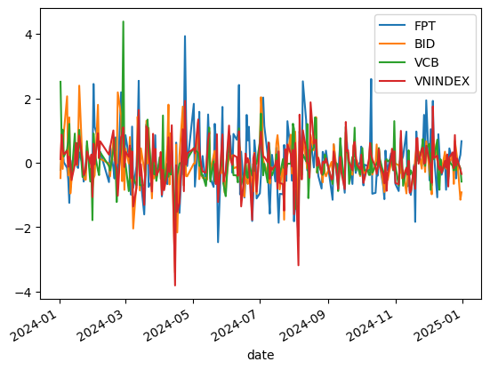

```python
norm_returns = (mult_returns - mult_returns.mean(axis=0))/mult_returns.std(axis=0)
norm_returns.loc['2024-01-01':'2025-01-01',].plot();
```

Điều này giúp dễ dàng so sánh chuyển động của các chuỗi thời gian khác nhau có trong ví dụ của chúng ta.

Tính trung bình động và độ lệch chuẩn cũng hoạt động với DataFrames.

```python
rolling_mean = prices.rolling(30).mean()
rolling_mean.columns = prices.columns
```

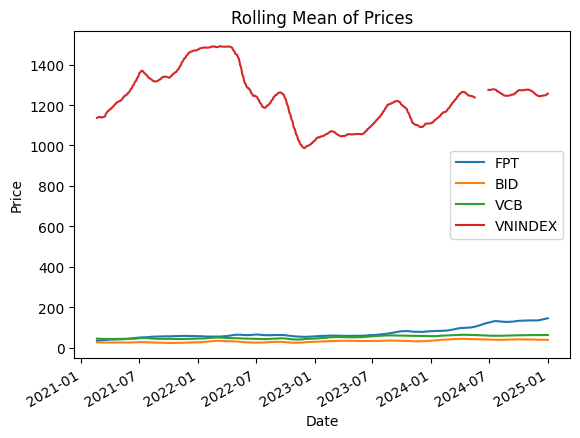

```python
rolling_mean.plot()
plt.title("Rolling Mean of Prices")
plt.xlabel("Date")
plt.ylabel("Price")
plt.legend();
```

Để có danh sách đầy đủ tất cả các phương thức được tích hợp trong `DataFrame`, hãy xem [tài liệu](https://pandas.pydata.org/pandas-docs/stable/reference/api/pandas.DataFrame.html).

*Lưu ý: Tài liệu này mang tính chất chia sẻ kiến thức khoa học dữ liệu. Các mã chứng khoán xuất hiện trong tài liệu chỉ mang tính chất minh hoạ, không khuyến nghị đầu tư. Chúng tôi không chịu trách nhiệm trước mọi rủi ro nào do sử dụng tài liệu này.*